# Global FoodOmics - U19 - ADNI

Exploratory Analysis

Kiana A West

2021-10-13

Make output directory

```r
if (!dir.exists(params$save_dir)) { system(paste("mkdir", params$save_dir)) }
```

Load packages

```r
pacman::p_load("plotly", "tidyverse", "magrittr", "ggpubr", "jtools")
```

Read in files

```r
ont <- read_delim(params$ont_file, delim = "\t") %>%
  filter(!duplicated(sample_name)) # two food samples with same name - keep one
meta <- read_csv(params$meta_file) %>%
  filter(RID != "RID999999") # remove non-clinical samples
         # !duplicated(RID))
f_counts <- read_csv(params$f_counts_file) %>%
  filter(filename %in% meta$SampleID) # keep only samples with metadata
imp_var <- read_csv(params$imp_var) # variables of interest
```

Format data

```r
f_counts_mat <- set_rownames(as(f_counts[,-1], "matrix"), f_counts$filename)

ont <- set_rownames(as(ont, "matrix"), ont$sample_name)

meta <- set_rownames(as.data.frame(meta), meta$SampleID)
```

Transform food counts at specific levels to proportions

```r
transform_f_counts <- function(f) {
  fc <- read_csv(f)
  filenames <- fc$filename
  fc <- fc %>%
    dplyr::select(-filename) %>%
    apply(., 1, function(x) {ifelse(x != 0, x/sum(x), 0)}) %>%
    t() %>%
    data.frame() %>%
    set_rownames(make.names(filenames))
  return(fc)
}

f_counts_L3 <- transform_f_counts("../data/ADNI_food_counts_L3.csv")
f_counts_L3 <- f_counts_L3[row.names(f_counts_L3) %in% meta$SampleID,]
f_counts_L4 <- transform_f_counts("../data/ADNI_food_counts_L4.csv")
f_counts_L4 <- f_counts_L4[row.names(f_counts_L4) %in% meta$SampleID,]
f_counts_L5 <- transform_f_counts("../data/ADNI_food_counts_L5.csv")
f_counts_L5 <- f_counts_L5[row.names(f_counts_L5) %in% meta$SampleID,]
```

# PCA of food counts

Model CLR transformed data (individual food counts i.e. no ontology level) to observe variation in diet across cohort.

```r
clr_mat <- mixOmics::logratio.transfo(f_counts_mat,
                                      offset = 1, logratio = "CLR")
m <- mixOmics::pca(clr_mat,
                   ncomp = 3, center = T, scale = T)
# extract latent variables from model
df <- data.frame(m$variates$X, filename = m$names$sample, total_sum = rowSums(f_counts_mat),
                 unique_foods = apply(f_counts_mat, 1, function(x) {sum(x > 0)}))
# add proportional food counts at L3-L5
df <- left_join(meta, df, by = c("SampleID" = "filename")) %>%
  left_join(mutate(f_counts_L3, filename = row.names(f_counts_L3)), by = c("SampleID" = "filename")) %>%
  left_join(mutate(f_counts_L4, filename = row.names(f_counts_L4)), by = c("SampleID" = "filename")) %>%
  left_join(mutate(f_counts_L5, filename = row.names(f_counts_L5)), by = c("SampleID" = "filename"))
```

## Which food groups are correlated to PC1?

Get categories at each ontology level (L3-L5)

```r
ont_levels <- ont %>%
  data.frame() %>%
  dplyr::select(sample_type_group3, sample_type_group4, sample_type_group5) %>%
  gather(key = "ont_level", value = "food") %>%
  arrange(desc(ont_level)) %>%
  filter(food != "complex",
         !duplicated(food)) %>%
  mutate(food = make.names(food),
         ont_level = gsub("sample_type_group", "L", ont_level))
```

Calculate Spearman correlations

```r
to_cor <- dplyr::select(df, PC1, dairy:yogurt_cow)
# correlate whole matrix
cor_mat <- Hmisc::rcorr(as(to_cor, "matrix"), type = "spearman")
# keep PC1~each food
to_plot <- tibble(food = row.names(cor_mat$r)[-1], r = cor_mat$r[-1,"PC1"], p = cor_mat$P[-1,"PC1"]) %>%
  filter(!grepl("\\.x", food), # some foods are duplicated across ontology levels, keep lower level
         !food %in% c("honey", "seaweed")) %>% # these foods are found at 3 different levels (removing L3)
  arrange(r) %>%
  mutate(orig_term = food,
         food = as_factor(gsub("\\.y", "", food))) %>%
  left_join(ont_levels) %>%
  mutate(ont_level = factor(ont_level, levels = c("L3", "L4", "L5")))
# keep foods whose corr with PC1 has FDR<0.05 & |corr|>0.2
sig_foods <- subset(to_plot, p.adjust(to_plot$p, method = "BH") < 0.05 & abs(to_plot$r) > 0.2)
```

Plot all correlations at L3, L4, L5

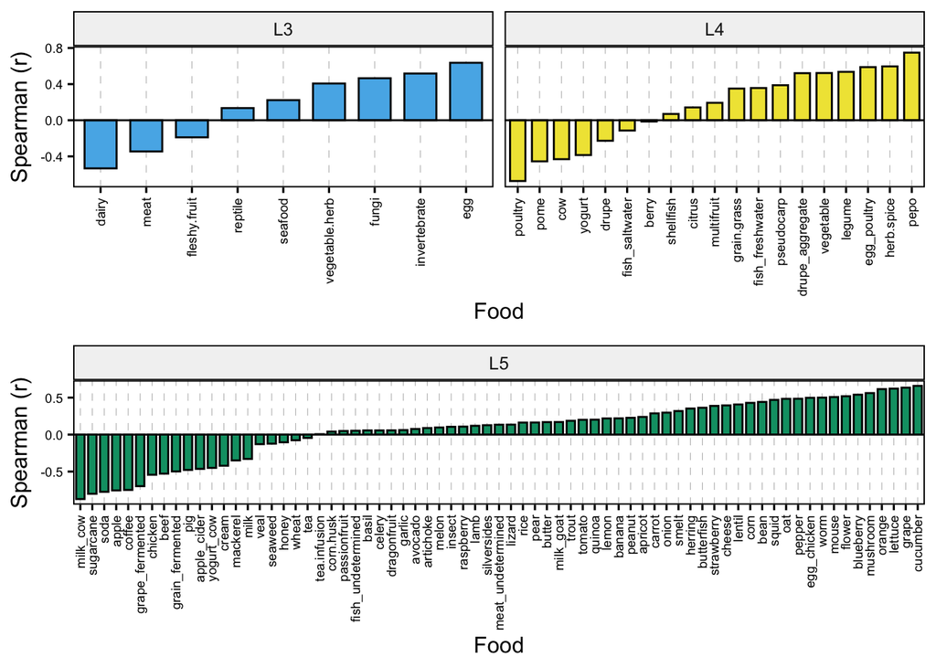

```r
# L3/4 plot
p1 <- ggbarplot(subset(to_plot, to_plot$ont_level != "L5"), x = "food", y = "r",
                fill = "ont_level", palette = c("#56B4E9", "#F0E442"),
                facet.by = "ont_level", scales = "free_x") +
  labs(y = "Spearman (r)", x = "Food", fill = "Ontology Level") +
  rotate_x_text(angle = 90) +
  geom_hline(yintercept = 0) +
  theme(legend.position = "none",
        axis.text = element_text(size = 7),
        panel.grid.major.x = element_line(colour = "grey", size = 0.2, linetype = 2))
# L5 plot
p2 <- ggbarplot(subset(to_plot, to_plot$ont_level == "L5"), x = "food", y = "r",
                fill = "ont_level", palette = c("#009E73"),
                facet.by = "ont_level", scales = "free_x") +
  labs(y = "Spearman (r)", x = "Food", fill = "Ontology Level") +
  rotate_x_text(angle = 90) +
  geom_hline(yintercept = 0) +
  theme(legend.position = "none",
        axis.text = element_text(size = 7),
        panel.grid.major.x = element_line(colour = "grey", size = 0.2, linetype = 2))
(p <- ggarrange(p1, p2, nrow = 2))
```

```r
ggsave(filename = file.path(params$save_dir, "correlations_between_PC1_food_categories.pdf"), plot = p, height = 7, width = 9)
```

## Plot PCA scores colored by each significant ontology category (L3-L5).

Saved as interactive html files

```r
for (f in c(sig_foods$orig_term,"AGE", "DX", "RAVLT_perc_forgetting_bl")) {
  p <- plot_ly(df, x = ~PC1, y = ~PC2, type = "scatter", mode = "markers", color = ~get(f), #symbol = ~class,
               marker = list(size = 10, width = 2, line = list(color = "black", width = 2))) %>%
        layout(title = str_replace_all(f, c("\\.x" = "", "\\.y" = "")),
               xaxis = list(title = paste0("PC1", " [", round(m$prop_expl_var$X[1]*100, digits = 1), "%]"), size = 18),
               yaxis = list(title = paste0("PC2", " [", round(m$prop_expl_var$X[2]*100, digits = 1), "%]"), size = 18))
  htmlwidgets::saveWidget(p, file = file.path(params$save_dir, paste0("PCA_CLR_allSamp_food_counts_colorBY_", f, ".html")))
}
```

# Is diet variation related to metadata?

Calculate linear mixed-effects models. Models 1-4 include multiple samples from some individuals and adjust for repeated measures. Models 5-6 include a single sample from each individual.

```r
# all samples (for models 1-4)
df1 <- df %>%
  mutate(DX = factor(DX, levels = c("CN", "MCI", "Dementia")),
         DX_bl = factor(DX_bl, levels = c("CN", "SMC", "EMCI", "LMCI", "AD")))
# single sample per individual (for models 5-6)
df2 <- df %>%
  filter(!duplicated(RID)) %>%
  mutate(DX = factor(DX, levels = c("CN", "MCI", "Dementia")),
         DX_bl = factor(DX_bl, levels = c("CN", "SMC", "EMCI", "LMCI", "AD")))
```

Models 1-4

```r
m1 <- lme4::lmer(PC1 ~ DX_bl + AGE + PTGENDER + RAVLT_perc_forgetting_bl + (1|Plate) + (1|RID),
          data = df1)
```

```
## boundary (singular) fit: see ?isSingular
```

```r
mres1 <- as.data.frame(anova(m1)) %>% # obtain sum of squares for fixed effects
  set_colnames(make.names(colnames(.))) %>%
  mutate(term = row.names(.),
         var = 100*(Sum.Sq/sum(Sum.Sq))) # calculate % variance explained for each fixed effect

m2 <- lme4::lmer(PC1 ~ DX + AGE + PTGENDER + RAVLT_perc_forgetting_bl + (1|Plate) + (1|RID),
                 data = df1)
```

```
## boundary (singular) fit: see ?isSingular
```

```r
mres2 <- as.data.frame(anova(m2)) %>%
  set_colnames(make.names(colnames(.))) %>%
  mutate(term = row.names(.),
         var = 100*(Sum.Sq/sum(Sum.Sq)))

m3 <- lme4::lmer(PC1 ~ DX_bl + AGE + PTGENDER + RAVLT_perc_forgetting_bl + (1|RID),
                 data = df1)
```

```
## boundary (singular) fit: see ?isSingular
```

```r
mres3 <- as.data.frame(anova(m3)) %>%
  set_colnames(make.names(colnames(.))) %>%
  mutate(term = row.names(.),
         var = 100*(Sum.Sq/sum(Sum.Sq)))

m4 <- lme4::lmer(PC1 ~ DX + AGE + PTGENDER + RAVLT_perc_forgetting_bl + (1|RID),
                 data = df1)
```

```
## boundary (singular) fit: see ?isSingular
```

```r
mres4 <- as.data.frame(anova(m4)) %>%
  set_colnames(make.names(colnames(.))) %>%
  mutate(term = row.names(.),
         var = 100*(Sum.Sq/sum(Sum.Sq)))
```

Models 5-6

```r
m5 <- lme4::lmer(PC1 ~ DX_bl + AGE + PTGENDER + RAVLT_perc_forgetting_bl + (1|Plate),
          data = df2)
mres5 <- as.data.frame(anova(m5)) %>%
  set_colnames(make.names(colnames(.))) %>%
  mutate(term = row.names(.),
         var = 100*(Sum.Sq/sum(Sum.Sq)))

m6 <- lme4::lmer(PC1 ~ DX + AGE + PTGENDER + RAVLT_perc_forgetting_bl + (1|Plate),
                 data = df2)
mres6 <- as.data.frame(anova(m6)) %>%
  set_colnames(make.names(colnames(.))) %>%
  mutate(term = row.names(.),
         var = 100*(Sum.Sq/sum(Sum.Sq)))
```

Plot effect sizes (DX_bl: m1, m3, m5)

```r
to_plot1 <- plot_summs(m1, scale = TRUE)$data %>% # get regression coefficients
  mutate(group = plyr::mapvalues(x = term, # change variable labels for plot
                                 from = term,
                                 to = c("SMC", "EMCI", "LMCI", "AD",  "AGE", "GENDER", "PERC_FORGETTING")),
         group = factor(group, levels = rev(unique(group))),
         # need to re-group fixed effects (remove categories from label) to merge with sum.sq/%var data
         # sum.sq/%var is calculated for each fixed effect rather than each category within the variable
         # whereas regression coefficients are specific to each variable category (if non-numeric)
         term = gsub("DX.*", "DX_bl", term),
         Significance = ifelse(p.value < 0.05, "p<0.05", "p>0.05"),
         model = "All samples - adj by RID & Plate") %>%
  # add sum.sq/%var
  full_join(mres1, by = "term")
```

```
## boundary (singular) fit: see ?isSingular
```

```r
to_plot3 <- plot_summs(m3, scale = TRUE)$data %>%
  mutate(group = plyr::mapvalues(x = term,
                                 from = term,
                                 to = c("SMC", "EMCI", "LMCI", "AD",  "AGE", "GENDER", "PERC_FORGETTING")),
         group = factor(group, levels = rev(unique(group))),
         term = gsub("DX.*", "DX_bl", term),
         Significance = ifelse(p.value < 0.05, "p<0.05", "p>0.05"),
         model = "All samples - adj by RID") %>%
  full_join(mres3, by = "term")
```

```
## boundary (singular) fit: see ?isSingular
```

```r
to_plot5 <- plot_summs(m5, scale = TRUE)$data %>%
  mutate(group = plyr::mapvalues(x = term,
                                 from = term,
                                 to = c("SMC", "EMCI", "LMCI", "AD",  "AGE", "GENDER", "PERC_FORGETTING")),
         group = factor(group, levels = rev(unique(group))),
         term = gsub("DX.*", "DX_bl", term),
         Significance = ifelse(p.value < 0.05, "p<0.05", "p>0.05"),
         model = "Single sample - adj by Plate") %>%
  full_join(mres5, by = "term")
to_plot <- rbind(to_plot1, to_plot3, to_plot5)
```

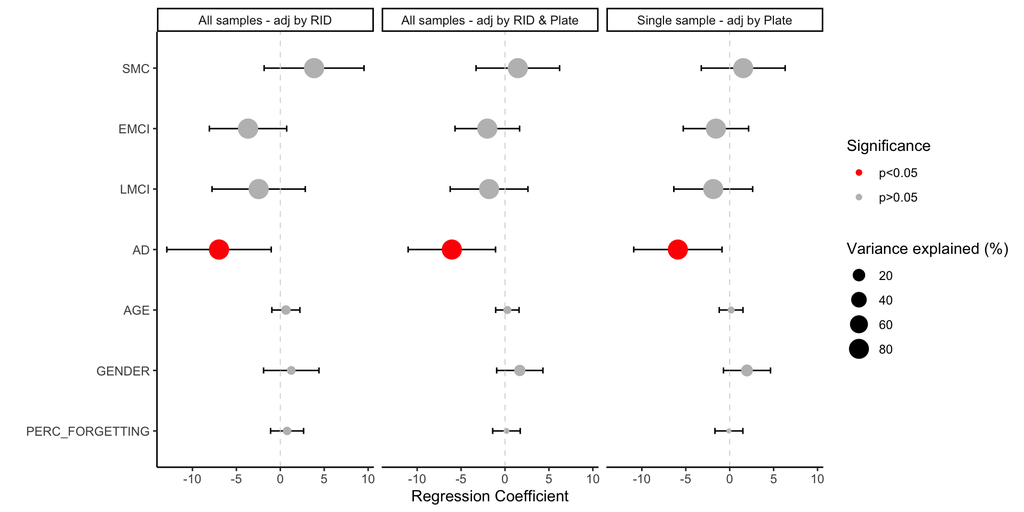

```r
p <- ggplot(data = to_plot,
            aes(x = group, y = estimate, colour = Significance,
                ymin = conf.low, ymax = conf.high,
                size = var)) +
  geom_errorbar(size = 0.5, width = 0.1, position = position_dodge(width=0.5), color = "black") +
  geom_point() +
  geom_hline(yintercept = 0, linetype = "dashed", size = 0.3, color = "lightgray") +
  scale_color_manual(values = c("red", "grey")) +
  coord_flip()+
  theme_classic() +
  labs(size = "Variance explained (%)",
       x = "",
       y = "Regression Coefficient")
(p <- facet(p, "model"))
```

```r
ggsave(filename = file.path(params$save_dir, "lme_PC1_DXbl.pdf"), plot = p, height = 5, width = 10)
```

Plot effect sizes (DX: m2, m4, m6)

```r
to_plot2 <- plot_summs(m2, scale = TRUE)$data %>%
  mutate(group = plyr::mapvalues(x = term,
                                 from = term,
                                 to = c("MCI", "Dementia",  "AGE", "GENDER", "PERC_FORGETTING")),
         group = factor(group, levels = rev(unique(group))),
         term = gsub("DX.*", "DX", term),
         Significance = ifelse(p.value < 0.05, "p<0.05", "p>0.05"),
         model = "All samples - adj by RID & Plate") %>%
  full_join(mres2, by = "term")
```

```
## boundary (singular) fit: see ?isSingular
```

```r
to_plot4 <- plot_summs(m4, scale = TRUE)$data %>%
  mutate(group = plyr::mapvalues(x = term,
                                 from = term,
                                 to = c("MCI", "Dementia",  "AGE", "GENDER", "PERC_FORGETTING")),
         group = factor(group, levels = rev(unique(group))),
         term = gsub("DX.*", "DX", term),
         Significance = ifelse(p.value < 0.05, "p<0.05", "p>0.05"),
         model = "All samples - adj by RID") %>%
  full_join(mres4, by = "term")
```

```
## boundary (singular) fit: see ?isSingular
```

```r
to_plot6 <- plot_summs(m6, scale = TRUE)$data %>%
  mutate(group = plyr::mapvalues(x = term,
                                 from = term,
                                 to = c("MCI", "Dementia",  "AGE", "GENDER", "PERC_FORGETTING")),
         group = factor(group, levels = rev(unique(group))),
         term = gsub("DX.*", "DX", term),
         Significance = ifelse(p.value < 0.05, "p<0.05", "p>0.05"),
         model = "Single sample - adj by Plate") %>%
  full_join(mres6, by = "term")
to_plot <- rbind(to_plot2, to_plot4, to_plot6)
```

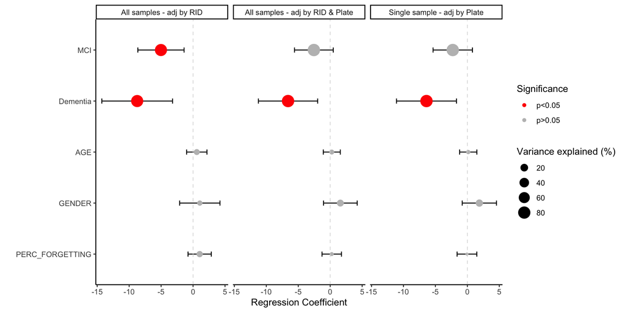

```r
p <- ggplot(data = to_plot,
            aes(x = group, y = estimate, colour = Significance,
                ymin = conf.low, ymax = conf.high,
                size = var)) +
  geom_errorbar(size = 0.5, width = 0.1, position = position_dodge(width=0.5), color = "black") +
  geom_point() +
  geom_hline(yintercept = 0, linetype = "dashed", size = 0.3, color = "lightgray") +
  scale_color_manual(values = c("red", "grey")) +
  coord_flip()+
  theme_classic() +
  labs(size = "Variance explained (%)",
       x = "",
       y = "Regression Coefficient")
(p <- facet(p, "model"))
```

```r
ggsave(filename = file.path(params$save_dir, "lme_PC1_DX.pdf"), plot = p, height = 5, width = 10)
```

## Simplified model

Best fit models were with a single sample per individual

```r
df1 <- df %>%
  filter(!duplicated(RID)) %>%
  mutate(DX = factor(DX, levels = c("CN", "MCI", "Dementia")),
         DX_bl = factor(DX_bl, levels = c("CN", "SMC", "EMCI", "LMCI", "AD")))

m1 <- lme4::lmer(PC1 ~ DX + AGE + PTGENDER + (1|Plate),
          data = df1)
mres1 <- as.data.frame(anova(m1)) %>%
  set_colnames(make.names(colnames(.))) %>%
  mutate(term = row.names(.),
         var = 100*(Sum.Sq/sum(Sum.Sq)))

to_plot1 <- plot_summs(m1, scale = TRUE)$data %>%
  mutate(group = plyr::mapvalues(x = term,
                                 from = term,
                                 to = c("MCI", "AD",  "AGE", "GENDER")),
         group = factor(group, levels = rev(unique(group))),
         term = gsub("DX.*", "DX", term),
         Significance = ifelse(p.value < 0.05, "p<0.05", "p>0.05"),
         model = "PC1") %>%
  full_join(mres1, by = "term")
```

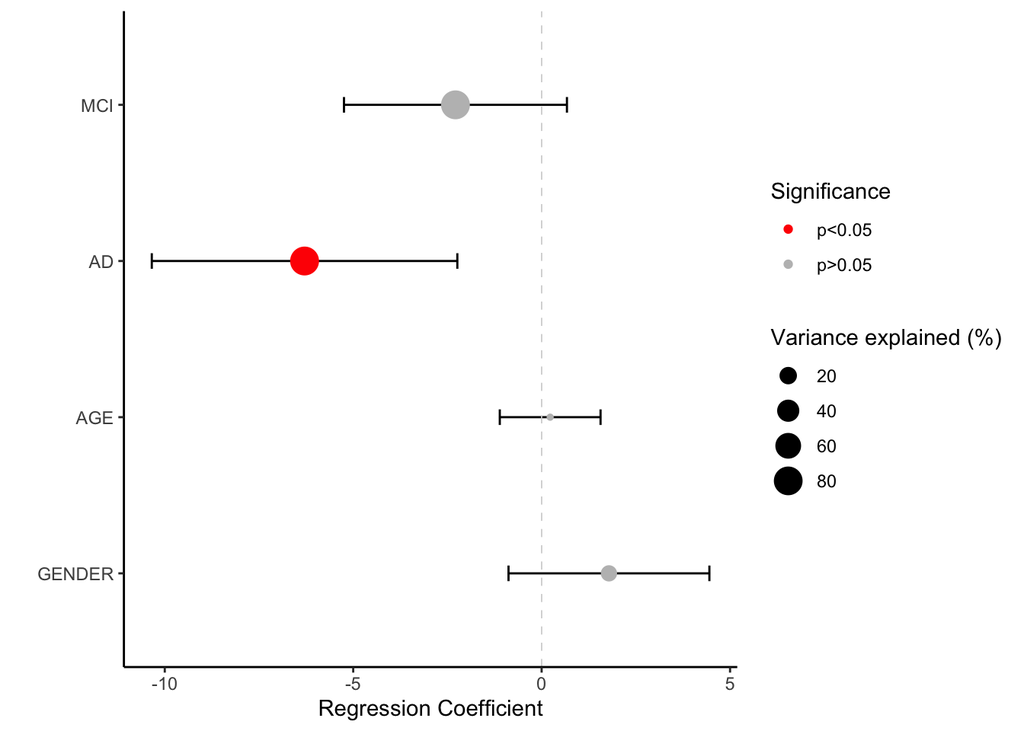

```r
(p <- ggplot(data = to_plot1,
            aes(x = group, y = estimate, colour = Significance,
                ymin = conf.low, ymax = conf.high,
                size = var)) +
  geom_errorbar(size = 0.5, width = 0.1, position = position_dodge(width=0.5), color = "black") +
  geom_point() +
  geom_hline(yintercept = 0, linetype = "dashed", size = 0.3, color = "lightgray") +
  scale_color_manual(values = c("red", "grey")) +
  coord_flip()+
  theme_classic() +
  labs(size = "Variance explained (%)",
       x = "",
       y = "Regression Coefficient"))
```

```r
ggsave(filename = file.path(params$save_dir, "lme_PC1_DX_forMS.pdf"), plot = p, height = 4, width = 6)
```

## Check models with variables of interest

Some of these are missing from the metadata we received

```r
imp_var$Variable
```

```
##  [1] "DX_bl"    "CMMED"    "SPARE_AD" "ADAS13"   "AGE"      "PTGENDER"
##  [7] "PTEDUCAT" "BIFAST"   "APOE4"    "TAU"      "VSWEIGHT" "VSHEIGHT"
## [13] "ABETA142"
```

```r
df1 <- df %>%
  filter(!duplicated(RID)) %>%
  mutate(DX_bl = factor(DX_bl, levels = c("CN", "SMC", "EMCI", "LMCI", "AD")))

m1 <- lme4::lmer(PC1 ~ DX_bl + AGE + PTGENDER + PTEDUCAT + APOE4 + TAU + (1|Plate),
          data = df1)
mres1 <- as.data.frame(anova(m1)) %>%
  set_colnames(make.names(colnames(.))) %>%
  mutate(term = row.names(.),
         var = 100*(Sum.Sq/sum(Sum.Sq)))

to_plot1 <- plot_summs(m1, scale = TRUE)$data %>%
  mutate(group = plyr::mapvalues(x = term,
                                 from = term,
                                 to = c("SMC" ,"EMCI","LMCI","AD","AGE","GENDER","EDUCATION","APOE4","TAU")),
         group = factor(group, levels = rev(unique(group))),
         term = gsub("DX_bl.*", "DX_bl", term),
         Significance = ifelse(p.value < 0.05, "p<0.05", "p>0.05"),
         model = "PC1") %>%
  full_join(mres1, by = "term")
```

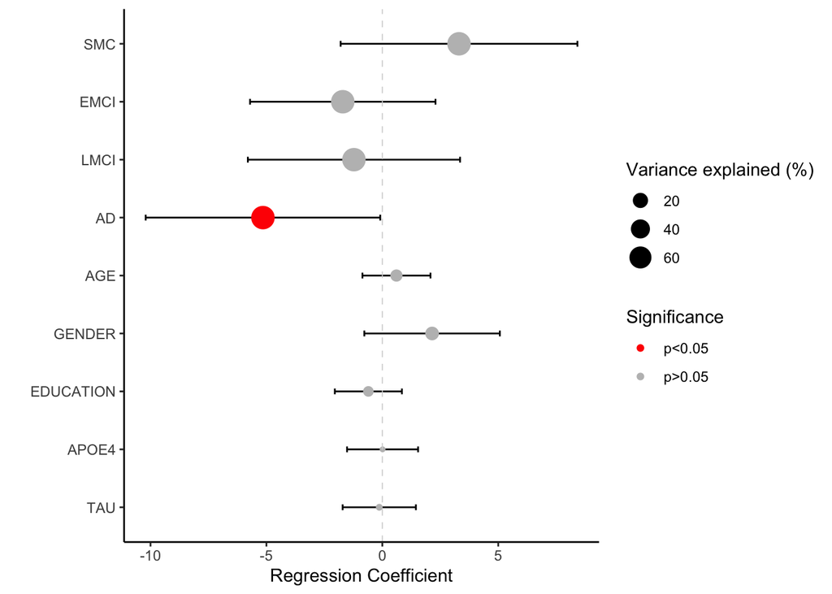

```r
(p <- ggplot(data = to_plot1,
            aes(x = group, y = estimate, colour = Significance,
                ymin = conf.low, ymax = conf.high,
                size = var)) +
  geom_errorbar(size = 0.5, width = 0.1, position = position_dodge(width=0.5), color = "black") +
  geom_point() +
  geom_hline(yintercept = 0, linetype = "dashed", size = 0.3, color = "lightgray") +
  scale_color_manual(values = c("red", "grey")) +
  coord_flip()+
  theme_classic() +
  labs(size = "Variance explained (%)",
       x = "",
       y = "Regression Coefficient"))
```

```r
ggsave(filename = file.path(params$save_dir, "lme_PC1_imp_var.pdf"), plot = p, height = 4, width = 6)
```